# research_idea_May_10_2019

Yiming

5/10/2019

# Sex difference in motion perception

### Aims:

```
  - Aim 1:  It answers whether difference of motion perception is caused by sex (physically inherited) or visual experience (environmental).
  - Aim 2:  It answers whether neural underpinning of sex difference in motion perception.
  - Aim 3:  Investigate whether male and female use different perceptual strategies which cause sex difference
```

## Preliminary analysis

Does the speed of optic flow of boy and girl infants differ in their active (walking/crawling) or negative (carrying) visual experience? It answers whether the activity preference or sex influence motion perception.

### speed comparison

```
##   X    ID mean_speed median_spd alpha kappa theta   r2 motion_status p05
## 1 1 006AP      19.72         15  0.85  1.01 17.40 0.98    Stationary   1
## 2 2 006AP      37.80         44  0.97  2.19 26.47 0.93        Moving   1
## 3 3 006MO      31.40         34  0.86  2.62 15.13 0.99        Moving   0
## 4 4 006MO      29.49         30  0.89  1.38 31.25 0.99    Stationary   0
## 5 5 009SS      18.80         16  0.76  1.25 15.75 0.98        Moving   1
## 6 6 009SS      27.97         42  0.75  1.86 31.41 0.97    Stationary   1
##   p01 p005 p0001 gender country
## 1   1    1     1 Female      US
## 2   1    1     1 Female      US
## 3   0    0     0   Male   India
## 4   0    0     0   Male   India
## 5   1    1     1 Female      US
## 6   1    1     1 Female      US
```

Plot (mean speed as DV)

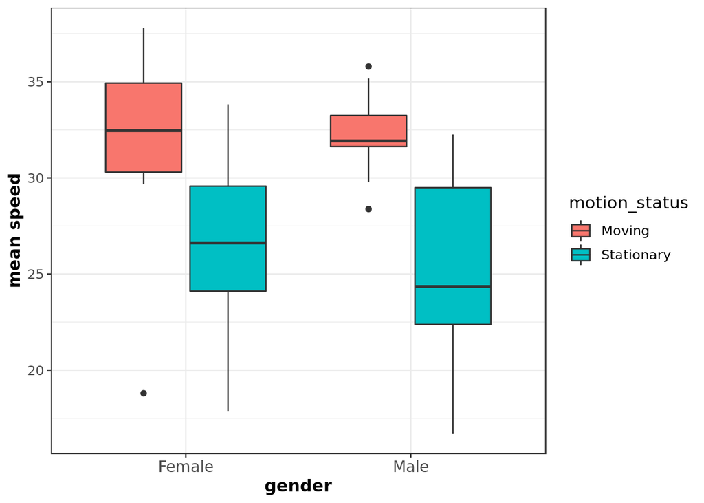

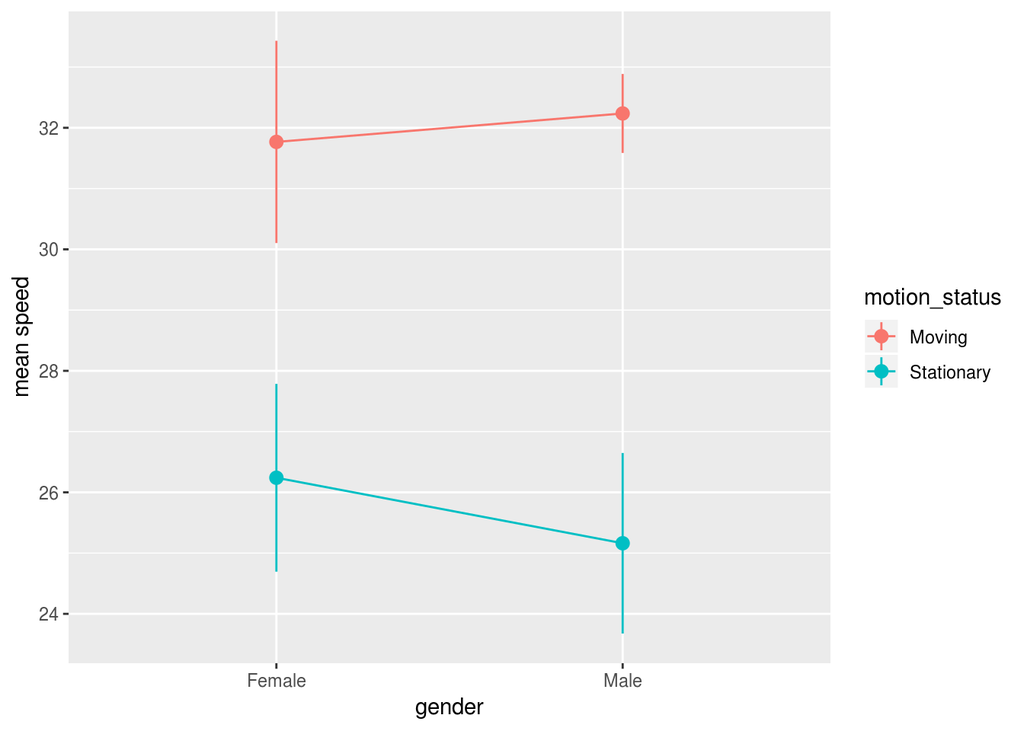

### Linear regression #### 3 IVs: gender, country and motion_status #### DV: mean_speed

```
##
## Call:
## lm(formula = mean_speed ~ gender + country + motion_status, data = spd_fits,
##     na.action = na.omit)
##
## Residuals:
##      Min       1Q   Median       3Q      Max
## -11.1373  -2.0181   0.2651   2.2642   7.8627
##
## Coefficients:
##                         Estimate Std. Error t value Pr(>|t|)
## (Intercept)              33.6636     1.2056  27.923  < 2e-16 ***
## genderMale                0.2371     1.2591   0.188  0.85164
## countryUS                -3.7263     1.2591  -2.960  0.00528 **
## motion_statusStationary  -6.3381     1.2442  -5.094  9.9e-06 ***
## ---
## Signif. codes:  0 '***' 0.001 '**' 0.01 '*' 0.05 '.' 0.1 ' ' 1
##
## Residual standard error: 4.032 on 38 degrees of freedom
## Multiple R-squared:  0.4778, Adjusted R-squared:  0.4366
## F-statistic: 11.59 on 3 and 38 DF,  p-value: 1.55e-05
```

### Linear Regression

#### DV: median_spd

```
##
## Call:
## lm(formula = median_spd ~ gender + country + motion_status, data = spd_fits,
##     na.action = na.omit)
##
## Residuals:
##      Min       1Q   Median       3Q      Max
## -18.9739  -4.8109  -0.1484   6.1899  18.8356
##
## Coefficients:
##                          Estimate Std. Error t value Pr(>|t|)
## (Intercept)              41.69200    2.47360  16.855  < 2e-16 ***
## genderMale               -0.03191    2.58328  -0.012   0.9902
## countryUS                -6.71809    2.58328  -2.601   0.0132 *
## motion_statusStationary -11.80952    2.55291  -4.626 4.24e-05 ***
## ---
## Signif. codes:  0 '***' 0.001 '**' 0.01 '*' 0.05 '.' 0.1 ' ' 1
##
## Residual standard error: 8.272 on 38 degrees of freedom
## Multiple R-squared:  0.427,  Adjusted R-squared:  0.3818
## F-statistic: 9.439 on 3 and 38 DF,  p-value: 8.596e-05
```

The insignifant gender difference makes some sense because infants have limited lomomotion ability and are often carried by caregivers.

### pattern comparison

```
##   X    ID video motion_status pattern_type start_fr end_fr n_frames
## 1 1 006AP     5    Stationary          exp    48162  48312      150
## 2 2 006AP     5    Stationary           cw    48162  48312      150
## 3 3 006AP     5    Stationary         left    48162  48312      150
## 4 4 006AP     5    Stationary           up    48162  48312      150
## 5 5 006AP     4    Stationary          exp    34106  34256      150
## 6 6 006AP     4    Stationary           cw    34106  34256      150
##   corr_bin_ctr corr_bin_count gender country
## 1           -1              0 Female      US
## 2           -1              0 Female      US
## 3           -1             36 Female      US
## 4           -1             36 Female      US
## 5           -1              0 Female      US
## 6           -1              0 Female      US
```

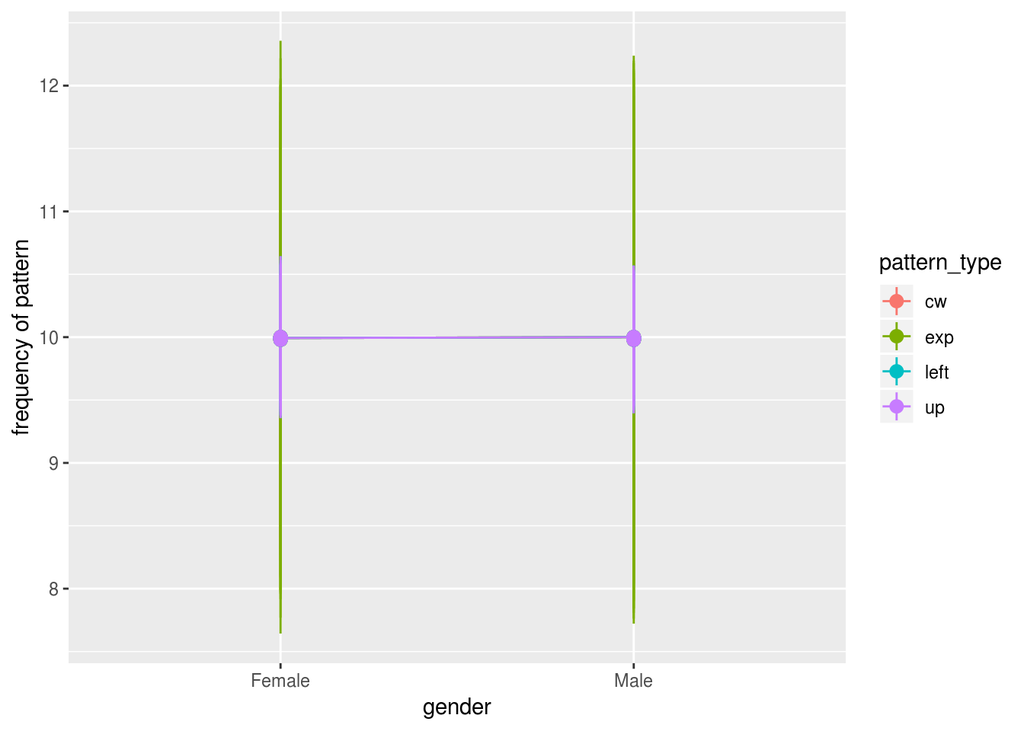

## Possible research projects

1. Does the choice and time for different type of toys (such as cars, dolls) influence the motion perception/spatial ability between boys and girls? Or motion perception influences toy choice? (Aim 1)
- Age range: 2-7
- Design: 2 measures: use camera to record children’s choice and time on each category of toys with various types of toys (and the time that children makes toys moving); psychophysical experiment on motion perception
2. Do the male infants/children pay more attention to the moving objects (Aim 1)?
- Age range: 1-3
- Design:eye-tracking experiment
3. Does visual experiences of female and male differ in older age? How is it correlated to motion perception performance/spatial ability? (Aim 1)
- Age range: 1-18
- Design: head camera (maybe some data can be collected in PLAY project)
4. Do males have faster response (ERP peak time) and higher activation (ERP/fMRI activation) to motion (Aim 2)?
- Age range: 1-18
- Design: ERP (check previous literature) and fMRI (refer to adult study of Murray et al., 2018)
5. Psychological orientation to thing/person (EEG or fMRI; previous finding showed there is same neural activation area and activation to human face)
6. Does Hormone (such as prenatal androgen) influence the amount of looking at moving objects/male-typed activity interests and engagement? (Aim 1) If so, does hormone correlated with motion perception performance/spatial ability?
7. (Maybe) When does sex difference occurs? (hard to do in infancy; Aim 1)